# Data, DataViz, and Stats with the Stars

Arvind V.

2025-06-28

## Agenda!

- Orange? What is this Orange stuff, anyhow?
- Throwing it All Away with Brad Pitt: Data Summaries
- Counting Letters with Sherlock Holmes: Bar Charts
- Nursery Rhymes with Ben Affleck: Line Charts
- Being a Mermaid with Katie Ledecky: Box Plots
- Jack and Rose lived happily ever after: Mosaic Plots
- The Art of Surprise with Gabbar Singh: Permutation Tests

## Orange? What is this Orange stuff, anyhow?

**Orange** is a visual drag-and-drop tool for

- Data visualization
- Statistical Tests
- Machine Learning
- Data mining

and much more. You can download and install Orange from here:

https://orangedatamining.com/download/

[figure not shown]

Figure 1: Orange Data Mining GUI

## Basic Usage of Orange

[video not shown]

## Widgets and Channels

[video not shown]

## The Orange Visual Interface

Let us create some simple visualizations using Orange.

- Use the `File Widget` to import the `iris` dataset into your session
- Use the `Data Table Widget` to look at the data, and note its variable names
- Use the `Visualization Widgets` ( Scatter Plot, Bar Plot, and Distributions) to look at the properties of the variables, and examine relationships between them.

## What does Data Look like?

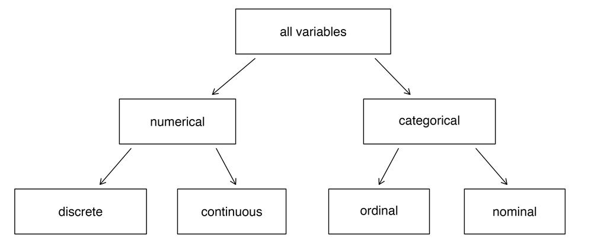

Variable Types

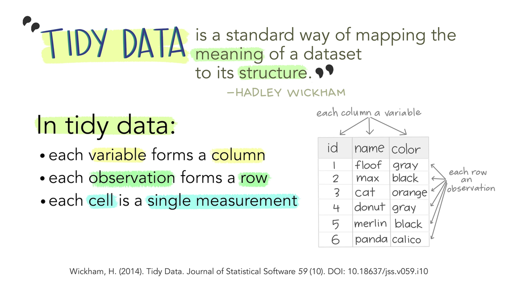

Tidy Data

## Orange Practice Session#1

- Let’s use the `Datasets` widget
- Click on it to select one of the built-in CSV files : `Auto MPG`
- Let’s look at the Data using the `Data Table` widget
- And create a Scatter Plot with the `Scatter Plot` widget (Horsepower vs Displacement)
- Try the menu options on the left side to see how they alter the plot

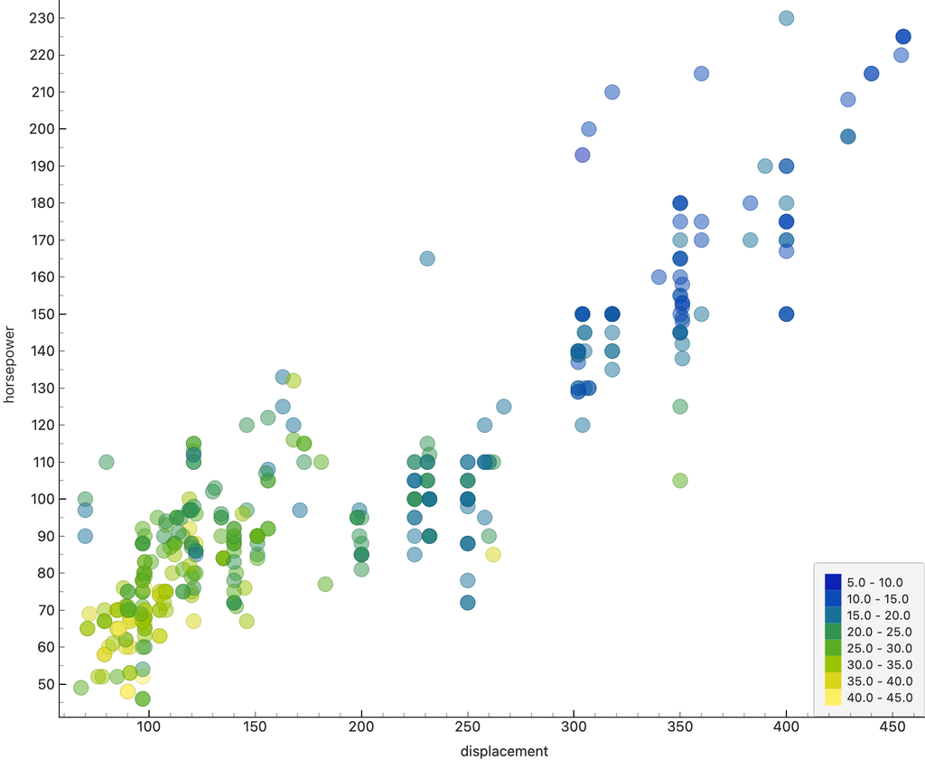

## Brad Pitt: Throwing it All Away

## Brad Pitt: Throwing it All Away

[video not shown]

## A Pillar of Statistical Wisdom

- One of the Big Ideas in Statistics is: *Aggregation*
- How is it revolutionary?
- By stipulating that, given a number of observations, you can actually gain information by throwing information away
- In taking a simple arithmetic mean, we discard the individuality of the measures, subsuming them to one summary.

[figure not shown]

## Brad Pitt: Throwing it All Away

### What was he throwing away?

**All the “Variables”**

- Age
- Previous Seasons
- Waist Size
- Treadmill Test Score
- Bat Speed?
- Smoke Weed?
- Girlfriend?
- Girlfriend Looks Rating?
- Waddles like a Duck?
- Looks Weird?

**And he was looking ONLY at…**

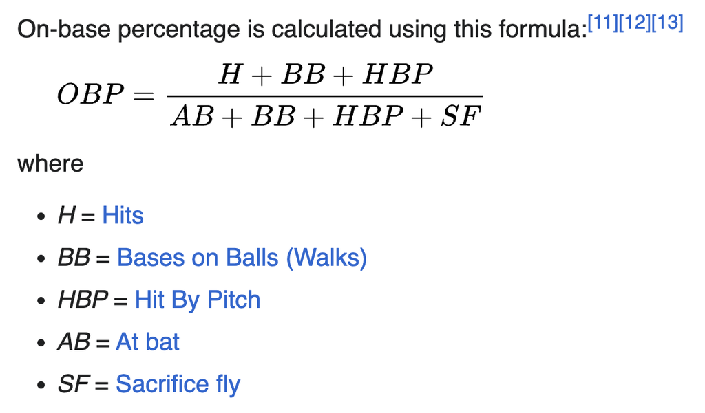

OBP Data

## How do we throw away data?

Before we plot a single chart, it is wise to take a look at several numbers that summarize the dataset under consideration. What might these be? Some obviously useful numbers are:

- Dataset length: How many rows/observations?
- Dataset breadth: How many columns/variables?
- How many Quant variables?
- How many Qual variables?
- Quant variables: min, max, mean, median, sd
- Qual variables: levels, counts per level
- Both: means, medians for each level of a Qual variable…

## Orange Practice Session #2

- So what do *we* throw away now? And how?
- Let’s look at the existing dataset, `Auto MPG`
- Pull in the `Feature Statistics` widget
- Connect the `Datasets` widget to the `Feature Statistics` widget
- Appreciate the Summary Statistics that are generated

## Wait, But Why?

- **To summarize is to understand**.
- Add to that the fact that our [Working Memories can hold maybe 7 items](https://www.wikiwand.com/en/The_Magical_Number_Seven,_Plus_or_Minus_Two), so it means information retention too.
- Borges wrote, “To think is to **forget details, generalize, make abstractions**. In the teeming world of [“Funes the Memorious,”](https://www.sas.upenn.edu/~cavitch/pdf-library/Borges_FunesTheMemorious.pdf), there were only details.”
- Brad Pitt aka Billy Beane was throwing away the details, and looking at the **aggregated** picture to pick his future Oakland A’s team.

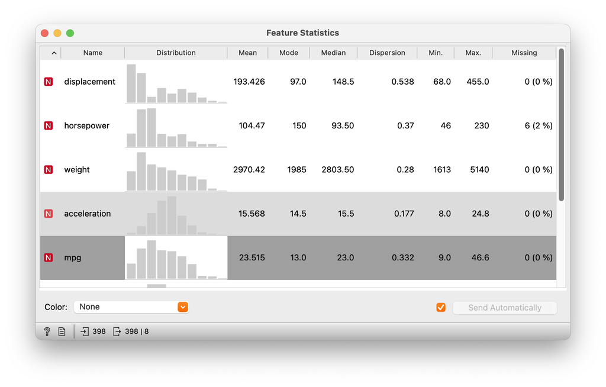

## Counting Letters with Sherlock Holmes

## Sherlock Holmes: The Adventure of the Dancing Men

In the Sherlock Holmes story, [The Adventure of the Dancing Men](https://www.gutenberg.org/files/108/108-h/108-h.htm#chap03), a criminal known to one of the characters communicates with her using a childish/child-like drawing which looks like this:

[figure not shown]

Am Here, Abe Slaney

How would Holmes decipher this message?

## Sherlock Holmes: The Adventure of the Dancing Men

- Using Conjectures:
- Symbols -> Letters
- Based on well-known *Counts* of letters (Zipf’s Law)
- Holmes deduces that the most common letter in the message is “E”
- He then deduces that the second most common letter is “T”

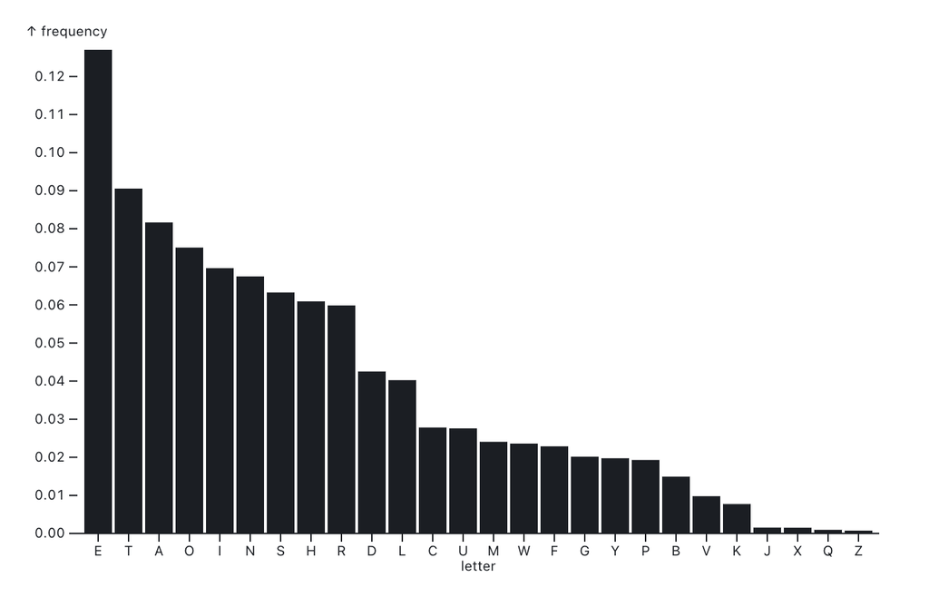

Zipf’s Law

## What Charts work for counting?

| Variable #1 | Variable #2 | Chart Names | Chart Shape |
| --- | --- | --- | --- |
| Qual | None | Bar Chart |  |

- Bar charts are used to show “counts” and “tallies” with respect to Qual variables.
- For instance, in a survey, how many people vs Gender?
- In a Target Audience survey on *Weekly Consumption*, how many low, medium, or high expenditure people?
- NOTE: we count with Qual variables! (Why? We count labels, like letters.)
- Which is why the Bars are not touching each other.

## Orange Practice Session #3

#### Banned Books!!!

OK, Let’s get some data to count:

And let’s for now use a pre-set Workflow in Orange

[Download the Orange Barchart Workflow](https://www.dropbox.com/scl/fi/43nt7gaf67x3hxoql88qu/barchart.ows?rlkey=5d1wd1kja2i1kv6eazi1k3z6v&st=7rjtcejp&dl=0)

- We will look at the data
- Make a Data dictionary
- Identify the Qual and Quant variables
- Prepare Counts and Bar Charts wrt Qual variables
- In Orange! Point, Click, and See!

## Data Dictionary

#### Qualitative Variables

- `Author`: Author of the book (Qual)
- `Title`: Title of the book (Qual)
- `Origin`: Origin of the Challenge (Qual)
- `Type of Ban`: Type of ban on the book (Qual)
- `State`: State in which the book was banned (Qual)
- `District`: District in which the book was banned (Qual)
- `Origin`: Origin of the Challenge (Qual)

#### Quantitative Variables

- None

## Counting our Data

**Research Question**

Do some States ban more books than some others?

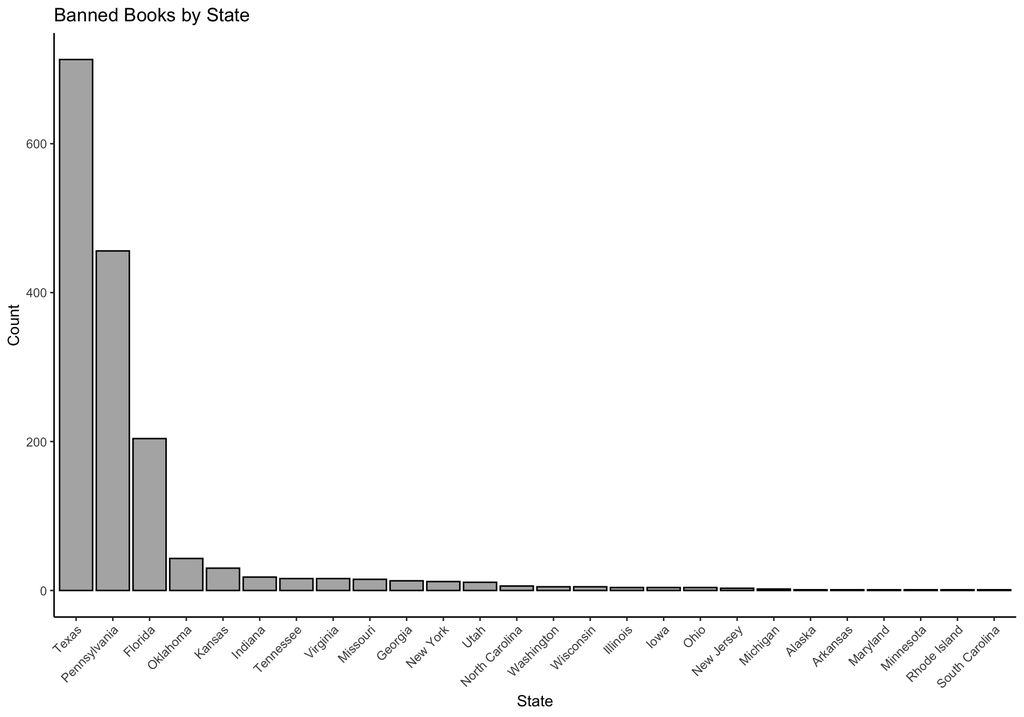

**What is the Story Here?**

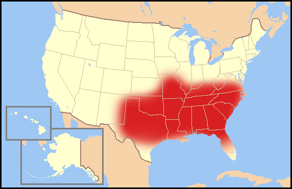

Figure 2: Bible Belt

## Counting our Data

**Research Question**

What are the kinds of bans that are being imposed on books? How many books banned by each type of ban?

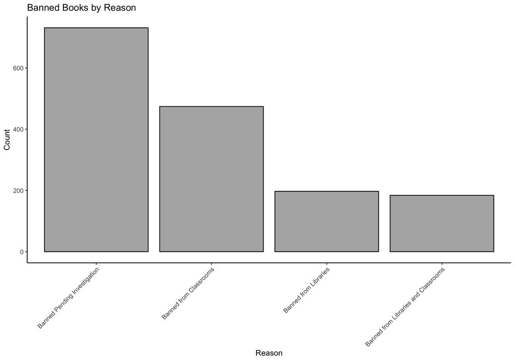

**What is the Story Here?**

- Four reasons for banning books
- “Investigation” is the commonest kind of ban
- How does one “investigate” a book???

## Wait, But Why?

- Counts first give you **an absolute sense of how much data you have**.
- Counts by different Qual variables give you a sense of the **combinations** you have in your data: $(State) * (District) * (Ban)$
- Counts then give an idea whether your data is lop-sided
- Since the X-axis in bar charts is *Qualitative* (the bars don’t touch, remember!) it is possible to sort the bars at will.

## Nursery Rhymes with Ben Affleck

## Nursery Rhymes with Ben Affleck

- In “The Accountant,” Christian Wolff is heard reciting “Solomon Grundy,”
- The nursery rhyme tells the life and death of a man named Solomon Grundy, **all within a single week**.
- It was innocently used to help children learn their days of the week.
- However, when we look into the fact that Thursday through Sunday detail the tragic end of Mr. Grundy due to an unspecified illness…
- it’s hard to ignore the dark undertones.

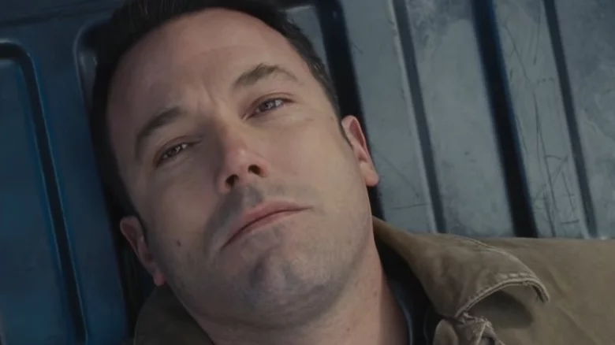

## What is the Data here? And the Chart?

- The data is the **days of the week**.
- The data is **the number of events that happen on each day**.
- The y-variable is a Quant variable, a number
- The x-variable is also Quant variable, a *time* variable

**Note**

Tourist: Any famous people born around here?  
Guide: No sir, best we can do is babies.

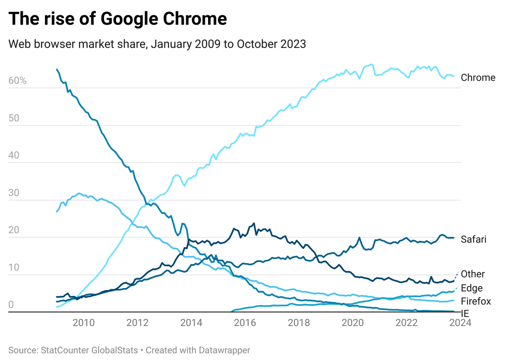

Line Chart for Time Series

## Timing our Data

OK, Let’s get some data to chart:

And let’s for now use a pre-set Workflow in Orange

[Download Orange Time Series Workflow](https://www.dropbox.com/scl/fi/pvklo0vwn6eruiqobvtzf/time-series.ows?rlkey=0gtv4gc9c6vfafd8us1ilc0s1&st=i88q99c3&dl=0)

- We will look at the data
- Make a Data dictionary
- Identify the Qual and Quant variables
- Prepare Time Series Charts with Quant variables, and Qual variables

## Data Dictionary

**Qualitative Variables**

- `year`: Year of birth (Qual)
- `month`: Month of the year (Qual)
- `day_of_month`: Day of the month (Qual)
- `day_of_week`: Day of the week (Qual)

**Quantitative Variables**

- `births`: Number of births on that day (Quant)

```
# A tibble: 6 × 5
   year month date_of_month day_of_week births
  <dbl> <dbl>         <dbl>       <dbl>  <dbl>
1  2000     1             1           6   9083
2  2000     1             2           7   8006
3  2000     1             3           1  11363
4  2000     1             4           2  13032
5  2000     1             5           3  12558
6  2000     1             6           4  12466
```

## Orange Practice Session#4

- The data is the number of births in the USA, by day, month, and year
- Let us use the `Group By` widget to group by `day_of_week`
- AND compute the `mean(births)` in the same widget
- We plot the `mean(births)` vs `month`, and colour by `day_of_week`

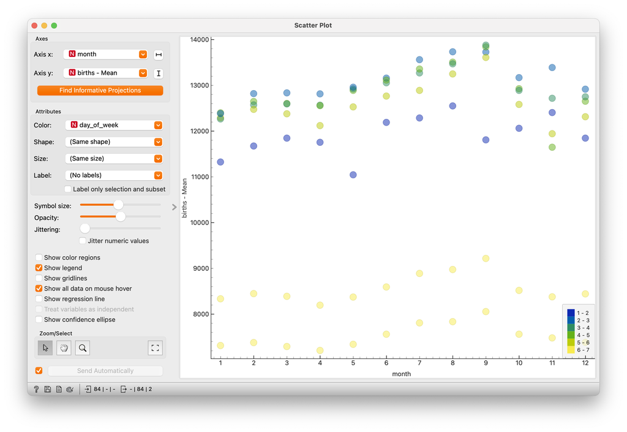

Mean Births Time Series

## Wait, But Why?

- Time series data is a special kind of Quantitative data, where the x-variable is a time variable.
- The y-variable is a Quant variable, a number.
- The x-variable is a Quant variable, a *time* variable.
- By colouring by `day_of_week`, we can see how the number of births varies by day of the week.

#### What is the Story Here?

- Could there be a staffing shortage at hospitals on weekends?
- Is this a “revealed preference” thing?
- Or should we watch Grey’s Anatomy, or even House?

## Being a Mermaid with Katie Ledecky

## Being a Mermaid with Katie Ledecky

[figure not shown]

- Katie Ledecky is a swimmer, and a mermaid.
- She has won 7 Olympic gold medals, and 15 World Championship gold medals.
- She is the world record holder in the 400, 800, and 1500 meter freestyle events, and in the 4x100 meter freestyle relay, and the 4x200 meter freestyle relay.
- What does that make her? *An Outlier*…

## So how do we find, and show, outliers?

- Outliers are data points that are significantly different from the rest of the data.
- They can be identified using *box plots*, which show the distribution of the data.
- Box plots show the median, quartiles, and outliers of the data.
- Of course, Ledecky was *in* the water! [Well in](https://www.open-bks.com/alice-87-88.html).

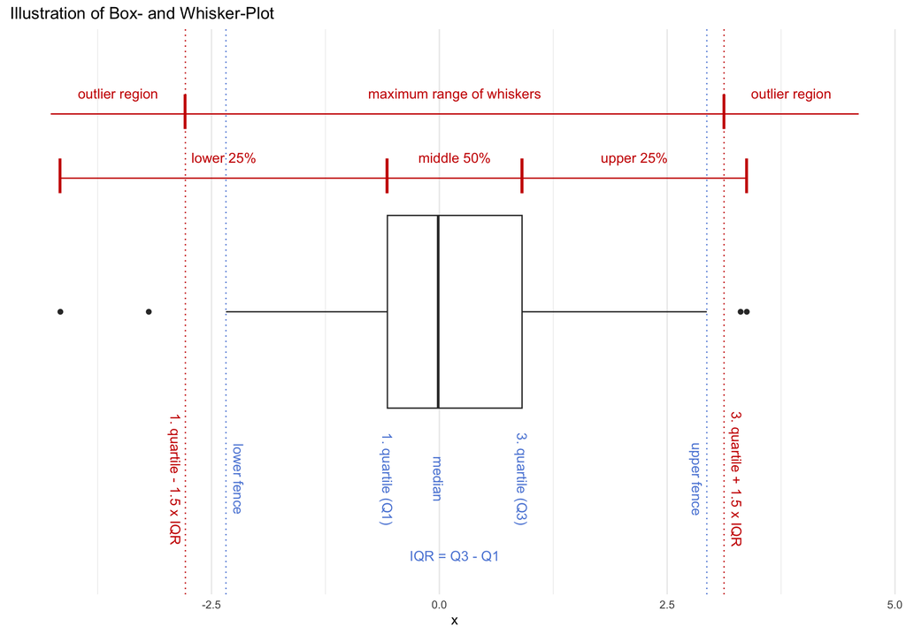

Figure 3: Box Plot Definitions

## Being an Outlier with Katie Ledecky

- Let’s get some data to plot:
- And let’s use a pre-set Workflow in Orange [Download the Orange Box Plot Workflow](https://www.dropbox.com/scl/fi/ylzcmochmyqgeoxdq141u/boxplots.ows?rlkey=izturtlnmnuw0oe96e1utmsar&st=tyisfg1a&dl=0)

## Data Dictionary

**Qualitative Variables**

- `rank`: Rank of the academic (Qual)
- `discipline`: Discipline of the academic (Qual)
- `sex`: Male / Female

**Quantitative Variables**

- `yrs.since.phd`: Years since PhD (Quant). Can be Qual??
- yrs.service`: Years of service (Quant)
- `salary`: Salary of the academic (Quant)

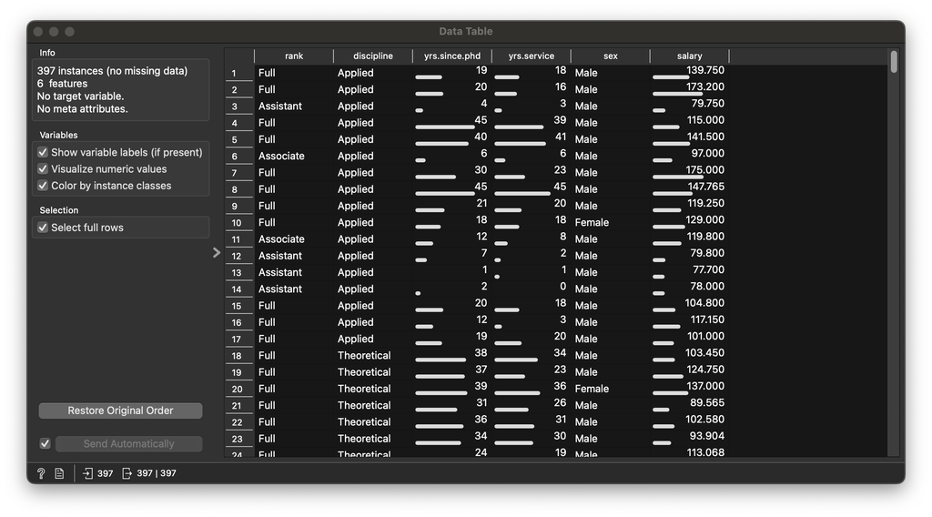

Figure 4: Salaries Data Table

## Research Question#1

**Question**

Q1. What is the distribution of `salary`? If we split by `sex`?

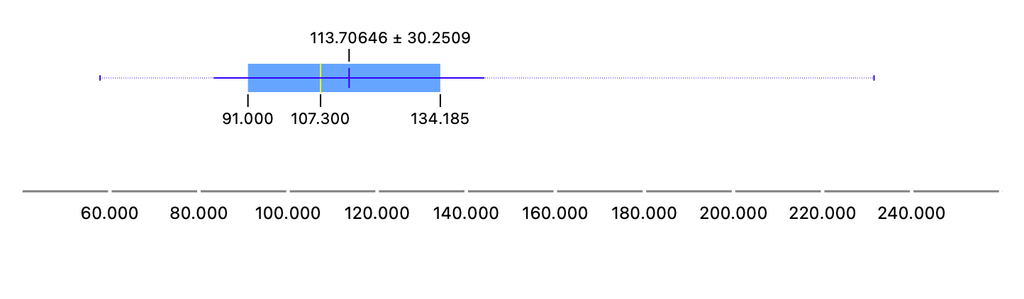

Figure 5: Salaries Box Plot

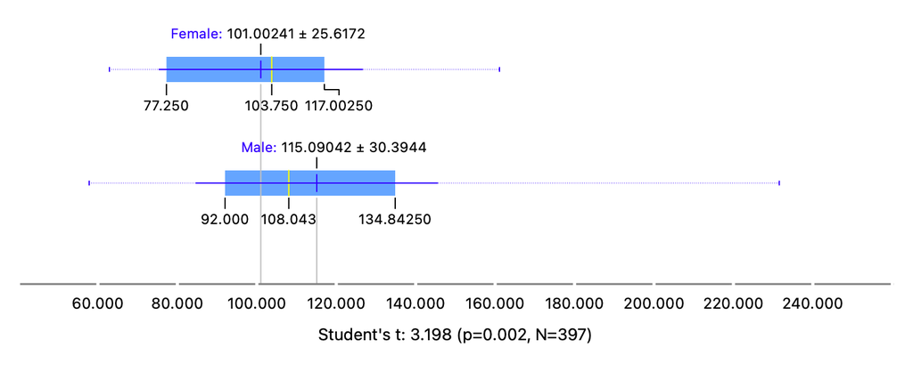

Figure 6: Salaries Box Plot by Sex

## Research Question#2

**Question**

Q2. What is the distribution of `salary`, when we split by other Qual variables, such as `rank`?

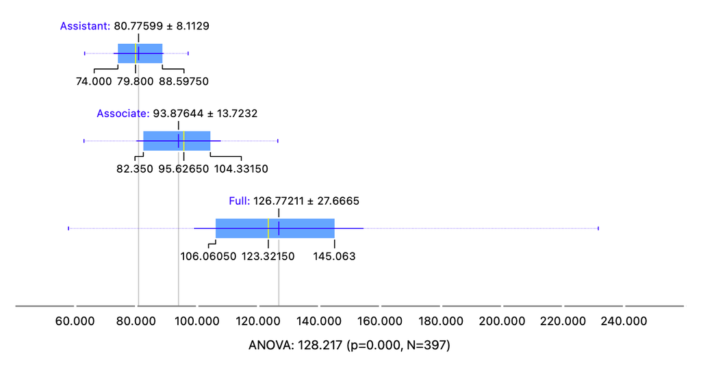

Figure 7: Salaries Box Plot by Rank

## Wait, But Why?

- Box Plots tell us distributions of Quant variables, and show us outliers.
- They show us the median, quartiles, and outliers of the data.
- They are useful for comparing distributions of Quant variables across Qual variables. ( E.g Sex or Rank)

#### What is the Story Here?

- Could there be a systemic bias in salaries?
- A statistical `t-test / ANOVA` would tell us if that is true.
- Look in the figures for a `t-test` and `ANOVA` report at the bottom.

## Jack and Rose lived happily ever after

## Jack and Rose lived happily ever after?

- The Titanic sank on 15 April 1912, after hitting an iceberg.
- What are the chances that Jack survived too?
- What did his chances depend on?

[figure not shown]

## Jack and Rose lived happily ever after?

- Let’s get the `titanic` data, using the `Datasets` widget in Orange.
- There were 2201 passengers, as per this dataset.
- And let’s use a pre-set Workflow in Orange

[Download the Orange Mosaic Chart Workflow](https://www.dropbox.com/scl/fi/a5zgvao3v2fir257wq2he/mosaic-chart.ows?rlkey=kl7hw5v5tzvdt9y97pwvadjsi&st=rnx0urbx&dl=0)

### Data Dictionary: `titanic`

**Quantitative Data**

None.

**Qualitative Data**

- `survived`: (chr) yes or no
- `status`: (chr) Class of Travel, else “crew”
- `age`: (chr) Adult, Child
- `sex`: (chr) Male / Female.

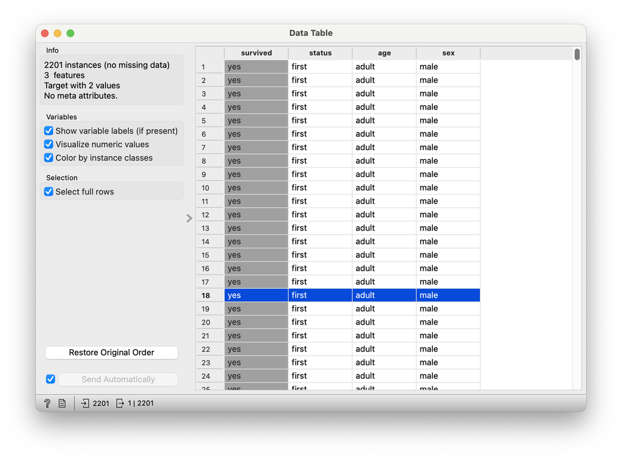

## What kind of Data Variables will we choose?

| Variable #1 | Variable #2 | Chart Names | Chart Shape |
| --- | --- | --- | --- |
| Qual | Qual | Pies, Mosaic Charts |  |

Here, $area \sim count$, so the area of the tile is proportional to the count of observations in that tile.

### Research Question #1

**Note**

What is the dependence of `survived` upon `sex`?

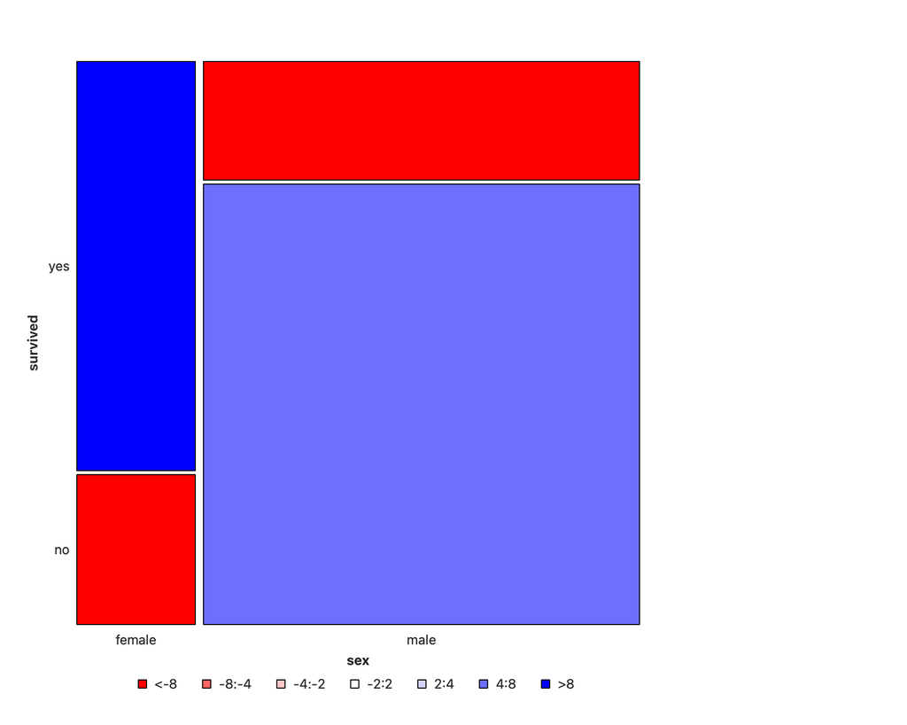

**Note**

- Note the huge imbalance in `survived` with `sex`
- Men have clearly perished in larger numbers than women.
- Colouring shows large *positive* residuals for men who died, and large *negative* residuals for women who died.

So sadly Jack is far more likely to have died than Rose.

### Research Question #2

**How does `survived` depend upon `status`?**

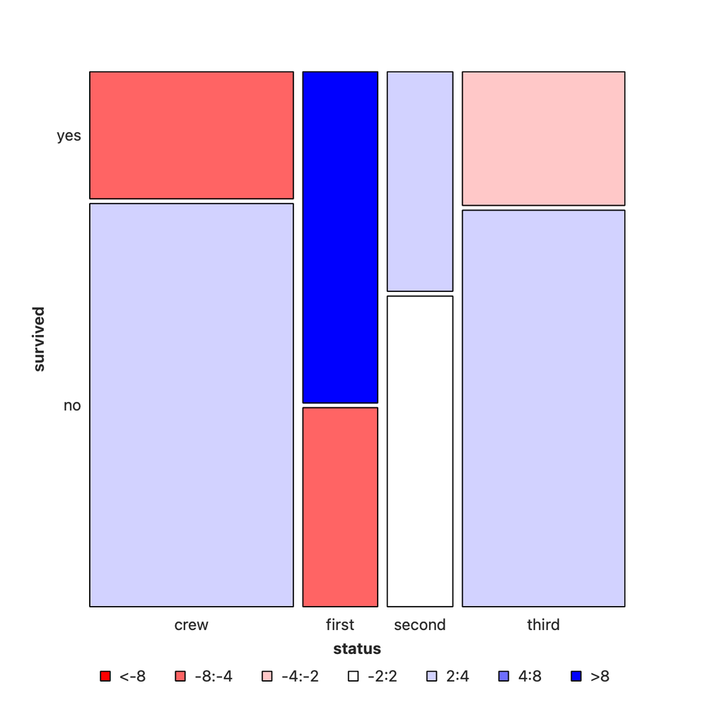

**Note**

- Crew has seen deaths in large numbers,
  - as seen by the large *negative* residual for crew-survivals.
- [First Class passengers have had speedy access to the boats](https://youtu.be/kQ8WsD9AGX4) and have survived in larger proportions than say second or third class.
- There is a large *positive* residual for first-class survivals.
- Rose travelled `first class` and Jack was `third class`. So again the odds are stacked against him.

## What are these Residuals anyhow?

When differences between the actual and expected counts are large, we deduce that one Qual variable has an effect on the other Qual variable. (speaking counts-wise or ratio-wise)

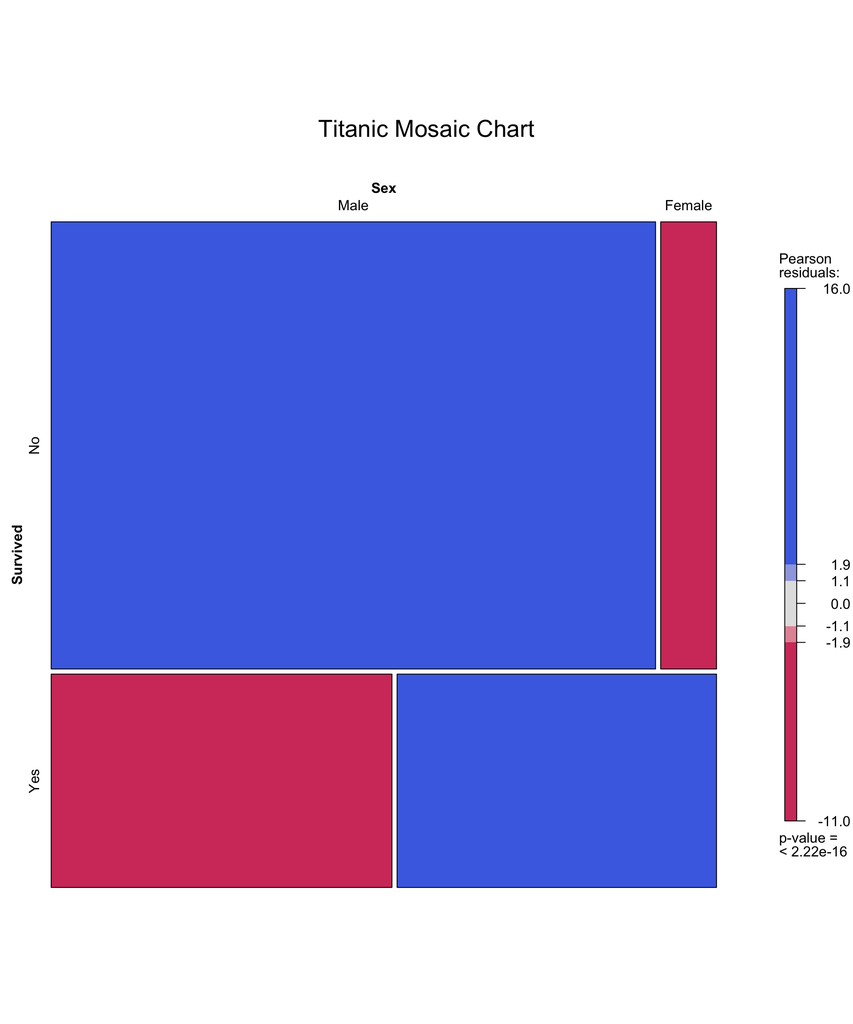

Actual Counts

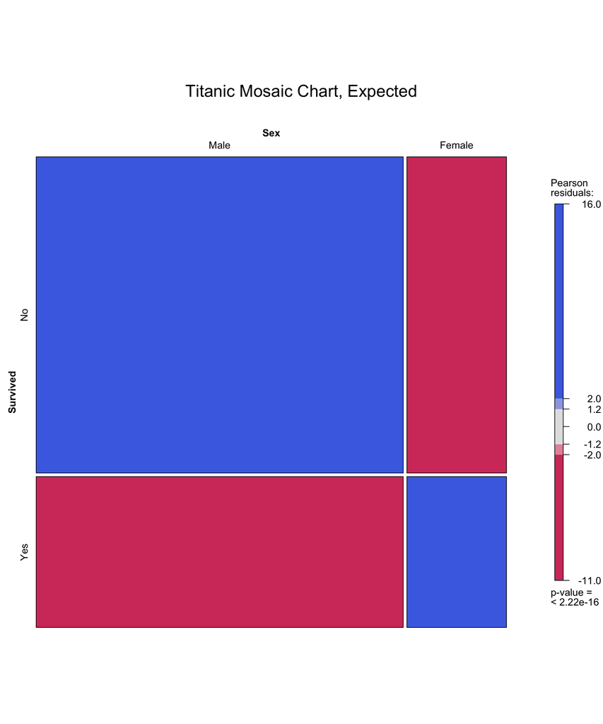

Expected Counts!!

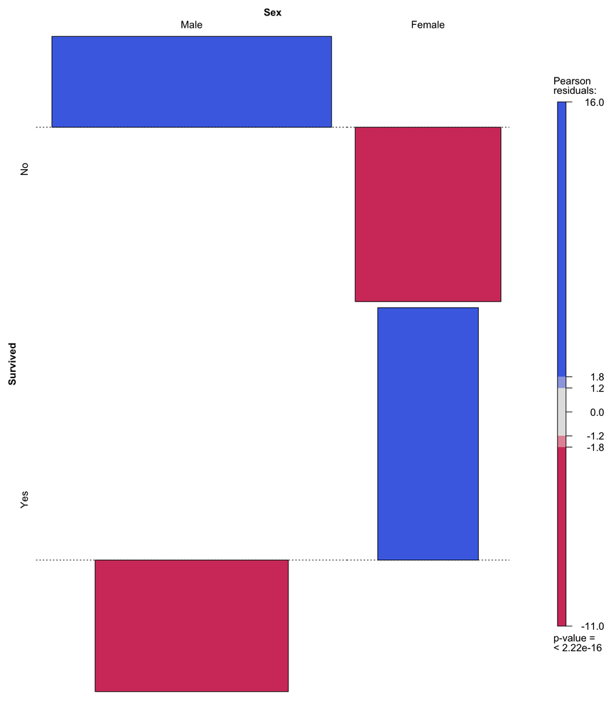

Tile-Wise Differences = Residuals

## Wait, But Why?

- Mosaic Charts are used to show the relationship between two Qual variables.
- They show the counts of observations in each combination of the two Qual variables.
- The area of each tile is proportional to the count of observations in that tile
- The colour of the tile shows the residuals, which are the differences between the actual and expected counts.

## The Art of Surprise with Gabbar Singh

## The Art of Surprise with Gabbar Singh

[video not shown]

## The Art of Surprise with Gabbar Singh

- What was the “data” Gabbar was looking at?

| Chamber | Bullet |
| --- | --- |
| 1 | Y / N |
| 2 | Y / N |
| .. | … |
| 6 | Y / N |

- The number of people in the village, and the number of people who were armed. (Quant)
- The number of bullets in the gun (Quant)
- The ID of the pistol chamber which contains a bullet (Qual)

## The Art of Surprise with Gabbar Singh

And Gabbar’s Hypothesis?

- That three bullets would never line up just ready to be fired, especially after he had fired three off!!
- So he could claim “ignorance”!
- “Ignorance” == “Fairness” == “Justice” !
- But he was *pretend-surprised* when the three bullets were lined up, and he could fire them all off at once!
- But no one could accuse him of anything, because he was “ignorant” of the fact that the bullets were lined up!

## Gabbar’s Gun Chamber Permutations

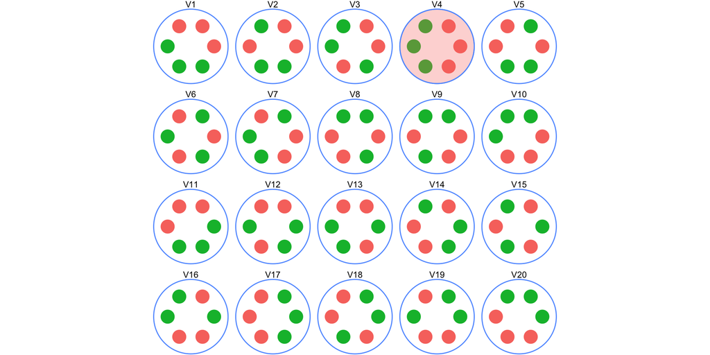

## So how do we become Gabbar Singh?

**[Are Emily and Greg more Employable than Lakisha and Jamal?](https://vincentarelbundock.github.io/Rdatasets/doc/AER/ResumeNames.html)**

Is ethnicity (as revealed by first names) a basis for racial discrimination, in the US?

This dataset was generated as part of a landmark research study done by [Marianne Bertrand and Senthil Mullainathan](https://sci-hub.se/10.1257/0002828042002561).

Read the description therein to really understand how you can *prove causality* with a well-crafted research experiment.

```
# A tibble: 6 × 3
  name    ethnicity call
  <chr>   <chr>     <fct>
1 Allison cauc      no
2 Kristen cauc      no
3 Lakisha afam      no
4 Latonya afam      no
5 Carrie  cauc      no
6 Jay     cauc      no
```

```
# A tibble: 4 × 3
# Groups:   ethnicity [2]
  ethnicity call      n
  <chr>     <fct> <int>
1 afam      yes     157
2 afam      no     2278
3 cauc      yes     235
4 cauc      no     2200
```

```
# A tibble: 2 × 2
  ethnicity call_prop
  <chr>         <dbl>
1 afam           6.45
2 cauc           9.65
```

[output not shown]

## The Art of Surprise with Gabbar Singh

- So it appears the call percentage is different for the two ethnicities, `afam` and `cauc`
- But is it statistically significant? Would Gabbar be surprised?
- Let us pretend `ethnicity` *does not matter* and spin the revolver!!
- We mess with the ethnicity variable, some 5000 times

```
[1] "diffprop"
```

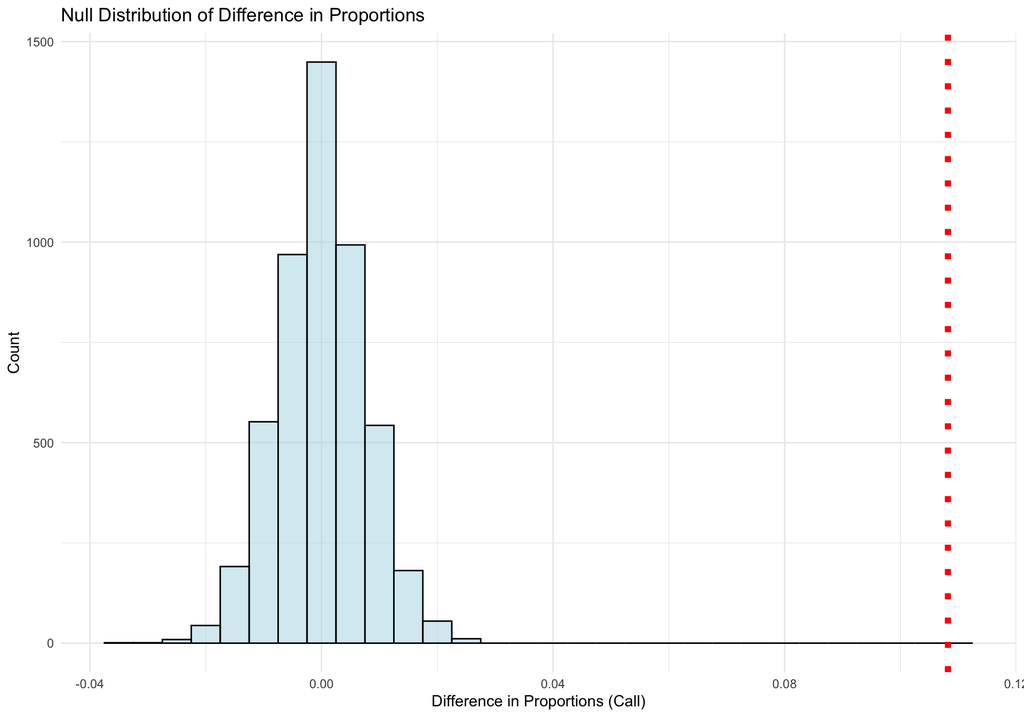

## The Art of Surprise with Gabbar Singh

```
[1] "diffprop"
```

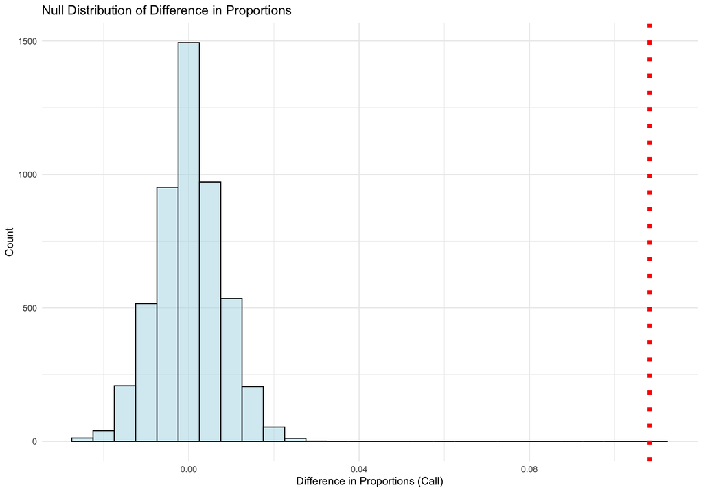

## Gabbar viv-a-vis a Stats Teacher

| Gabbar | Stats Teacher |
| --- | --- |
| “Kitne aadmi thay?” | How many observations do you have? n < 30 is a joke. |
| Kya Samajh kar aaye thay? Gabbar khus hoga? Sabaasi dega kya? | What are the levels in your Factors? Are they binary? Don’t do ANOVA just yet! |
| (Fires off three rounds ) Haan, ab theek hai! | Yes, now the dataset is balanced wrt the factor (Treatment and Control). |
| Is pistol mein teen zindagi aur teen maut bandh hai. Dekhte hain kisko kya milega. | This is our Research Question, for which we will Design an Experiment. |
| Hume kuchh nahi pataa! | Let us perform a non-parametric Permutation Test for this Factor! |
| Kamaal ho gaya! | Fantastic! Our p-value is so small that we can reject the NULL Hypothesis!! |

## Thank You!!

### Questions? Comments? Suggestions?

#### arvind.venkatadri@gmail.com

#### This Presentation: https://av-quarto.netlify.app/content/projects/modules/talks/vizchitra25/

#### Data and Workflow files are available at https://www.dropbox.com/scl/fo/15ha6pmtqd3t17c39idxi/AEviMggAcido-xQHiD82dH4?rlkey=h9xj09pdtx3st9basdfljwwyw&st=06dvqnbb&dl=0